# 使用 R vegan 套件分析植群

林政道 mutolisp@gmail.com

October 13, 2014

## 資料前處理

### 載入必要套件

先載入 vegan 套件，使用 `library(vegan)` ，如果你尚未安裝 vegan package，請用 `install.package(vegan)` 安裝。

```r
library(vegan)
```

### 匯入資料

使用 `read.csv()` 來匯入原始資料，你可以使用 excel 匯出 csv 檔案，或是使用 `read.xls()` (必須安裝 gdata 套件) 來匯入原始資料，在下面的例子中，我們將 plot_header.csv 檔讀進 R，並令這個物件名稱為 `raw_head`，species.csv 檔案亦是相同的處理方法

```r
# 載入原始資料，樣區物種資料為 species.csv，
# 樣區 header 資料為 plot_header.csv
raw_head = read.csv('plot_header.csv', header = T, row.names=1)
raw_plot = read.csv('species.csv', header = T)
```

匯入資料後，看一下資料的樣貌，可以使用 `head()` 來看資料表的前幾行，用 `dim()` 來看資料的維度（列數、欄數）

```r
head(raw_head)
```

```
##        altitude aspect slope  svf topo rock_r r_in_s
## 310494     3540    140     7 1.00    1    100      0
## 88136      3403    285    25 1.00    1     45     50
## 290052     3511    130    60 0.97    1     80     85
## 110117     3659     20    20 0.98    1     20     40
## 310492     3550    310     7 1.00    1    100      0
## 300063     3445    270    15 0.97    1     50     50
```

```r
dim(raw_head)
```

```
## [1] 333   7
```

```r
head(raw_plot)
```

```
##   plotid                                species cover
## 1 310494               Yushania niitakayamensis    58
## 2 310494         Rhododendron pseudochrysanthum     1
## 3 310494        Oxalis acetocella s. griffithii     1
## 4 310494 Chrysosplenium lanuginosum v. formosan     1
## 5 310494                          Festuca ovina     8
## 6 310494                      Gaultheria itoana     1
```

```r
dim(raw_plot)
```

```
## [1] 5501    3
```

上面的指令可以讓我們了解匯入資料的維度，欄位分別有哪些東西，這有助於初步的認識資料結構。接下來我們更進一步來看 header 中的環境因子。R 的資料結構分為 data frame, matrix, vector, list 等，預設是 data frame，你可以把它想像成是一個資料表的框架，裡頭每個格子裡都可以塞物品進去。在一個二維的 data frame 中，要細部拉出某個儲存的部件（例如第五列、第七欄，或是第三欄的第一列），都可以透過物件名稱加上中括號 `object[m,n]`(m 代表列數，n 代表欄數，也可以用 x:y 代表範圍)來取用，例如：

```r
# 顯示第一列
raw_head[1,]
```

```
##        altitude aspect slope svf topo rock_r r_in_s
## 310494     3540    140     7   1    1    100      0
```

```r
# 顯示第一欄，第 10 到第 20 列
raw_head[10:20,1]
```

```
##  [1] 3346 3402 3549 3206 3460 3633 3322 3300 3582 3500 3501
```

```r
# 也可以使用$欄位名稱來顯示資料
raw_head$slope
```

```
##   [1]  7 25 60 20  7 15 30 35 70 20 48 22 14 45 32 40 10 23 13 35 20 35 32
##  [24] 25 32 15  5 14 33 39 70 10 20 10  5 45 25 45 20 40 38 30  5 30 14  2
##  [47] 33 21 30 15 40 25 40 32 34 22 60 40 75 30 20 50 29 15 43 27 42 25 43
##  [70] 23 37 30 32 20 20 29 25 15 30 25 35  5 15 20 25 20 30 35 40 25 23 28
##  [93] 38 25 20 20 30 45 25 65 38 23 24 80 32 10 30 42 18 44 19 45 10 10 80
## [116] 22  5 33 30 15 30 10 30 20 10 30 20 10 35 37 40 30 20  5 42 25 10 30
## [139] 43 10 60 38  0  5 20 30 10 35  5 21 15 10 20 30 35  5 20 31  5 20 10
## [162] 30 40 20 10  0 25 30 30 10 40 20 25 27 36 45 15 30 28 20 40 31  5 10
## [185] 20  7 45 35 37 30 53 38 33 46 15 21 30 48 10  5 60 60 40 35 28 45 40
## [208] 45 21 10 34  7  1 45 20 27 35 32  5 28 25 48 35 33 33 32 35 35 35 40
## [231] 37 38 30 26 35 25 28 30 10 26 15  0 52 35 43 38 20 10 30 35 15 45  5
## [254] 60 40 40 45 45  1  0 20  5 35 15 60 30 42 20 41 25 25  5 20 35 23 20
## [277] 40 30 38  2 25 15 40 55 35 20 42 25 40 25 15 40 30 20 45 20 40 35 20
## [300] 25 65 10 45 39 21  0 40  5 26 55 20  5 45 15 12 35 27 17  5 33 35 35
## [323] 35 35 35 39 15  5 30 40 31 42 35
```

```r
# 也可以加入判斷式，例如我們想要取出坡度大於 50 的樣區
raw_head[raw_head$slope>50,]
```

```
##        altitude aspect slope  svf topo rock_r r_in_s
## 290052     3511    130    60 0.97    1     80     85
## 93151      3415     10    70 0.99    1      0    100
## 81019      3566    270    70 1.00    1     20    100
## 110310     3407      0    60 0.99    2     25     10
## 320481     3295    320    75 0.97    2     30     70
## 110491     3390    340    65 1.00    1     40     40
## 110488     3270     20    80 0.96    2      5     50
## 270072     3011     10    80 0.94    1     70     20
## 270012     3066     80    60 0.97    2      5     40
## 200511     2968    320    53 0.96    2     30      2
## 300186     2745     60    60 0.94    1     40     50
## 110404     2531     40    60 0.95    2      0     20
## 200509     3035    330    52 0.96    2     40      0
## 270015     2700     90    60 0.98    3      0     10
## 88047      2601     20    60 0.97    1      0      0
## 200080     3519    146    55 0.89    2     35     15
## 110417     3090    340    65 0.99    1     20     40
## 300264     3237     30    55 1.00    1     40     80
```

接下來可以用一些統計圖來視覺化我們的資料，最簡單的例子就是盒鬚圖(boxplot)

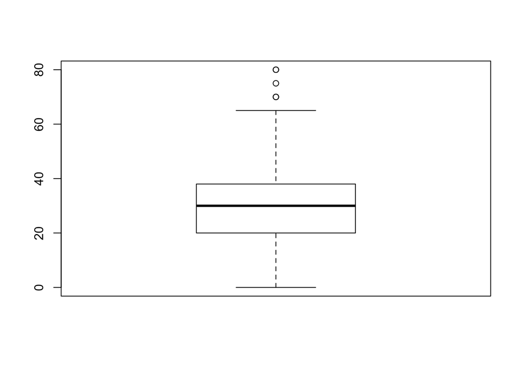

```r
# 顯示坡度的盒鬚圖，中間的粗線是中位數，方框上方是第三四分位數、
# 下方是第一四分位數; 最底下的線是最小值、最高的水平線是最大值。
# 而最大小值外部的圓圈是 R 自動計算出的 outlier
boxplot(raw_head$slope)
```

從上面的盒鬚圖可以觀察出我們資料中，坡度 50% 都是集中在 20–40 度之間。 之後希望能夠把多張盒鬚同時展示在同一張圖內，我們可以是用 `par(mfrow=c(m,n))` 來控制

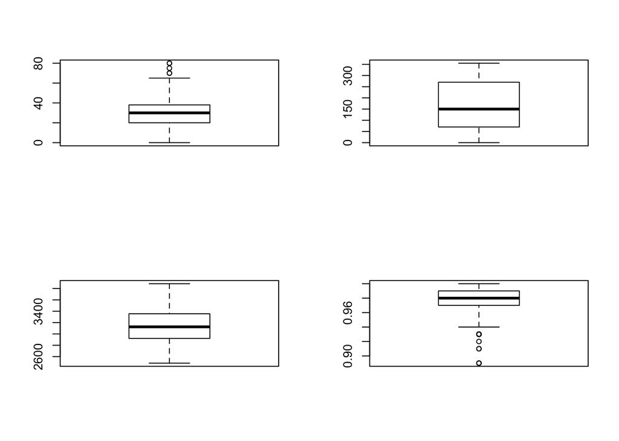

```r
par(mfrow=c(2,2))
boxplot(raw_head$slope)
boxplot(raw_head$aspect)
boxplot(raw_head$altitude)
boxplot(raw_head$svf)
```

## 序列分析

### 主成分分析(Principal Components Analysis; PCA)

```r
pca = princomp(raw_head)
summary(pca)
```

```
## Importance of components:
##                          Comp.1   Comp.2    Comp.3   Comp.4    Comp.5
## Standard deviation     296.5584 108.4940 28.493073 22.90218 14.467491
## Proportion of Variance   0.8685   0.1162  0.008017  0.00518  0.002067
## Cumulative Proportion    0.8685   0.9847  0.992743  0.99792  0.999990
##                           Comp.6    Comp.7
## Standard deviation     1.0115648 2.087e-02
## Proportion of Variance 0.0000101 4.302e-09
## Cumulative Proportion  1.0000000 1.000e+00
```

```r
#biplot(pca, display ="site", pch = 1)
```

在進行更進一步的梯度分析之前，將物種資料重新組成物種-樣區的格式(用`reshape()`)

```r
# 重新把資料表排成物種（欄）-樣區（列）的格式
veg_plot = reshape(raw_plot,timevar = "species", idvar="plotid",
  v.names=NULL, direction = "wide")
# 將欄位名稱存為 plotid
row.names(veg_plot) = veg_plot$plotid
# 移除
veg_plot = veg_plot[,2:dim(veg_plot)[2]]
# 把 NA 值取代為 0
veg_plot[is.na(veg_plot)] = 0
```

### 降趨對應分析(Detrended Correspondance Analysis; DCA)

```r
dca = decorana(veg_plot)
```

```r
veg_dist = vegdist(as.matrix(raw_head), method = "euclidean", diag=T)
hc = hclust(veg_dist, method = "average")
veg_group = cutree(hc, k = 9)
#rect.hclust(hc,9)
```